# Logistic Regression Through Numerical Optimization

Final Group 4

2022-12-02

# Package Overview

This R package contains functions designed to perform logistic regression on a user’s chosen response and predictor data. This is done through estimating the coefficient vector $\beta$ and which contains response and predictor data and the intercept. This is done using the function
$$\hat{\beta}\::=\underset{\beta}{\operatorname{argmin}}\sum_{i=1}^{n}(-y_{i}\cdot\ln(p_{i})-(1-y_{i})\cdot\ln(1-p_{i}))$$
where
$$p_{i}\::=\frac{1}{1+exp(-x_{i}^{T}\beta)}$$
with $y_{i}$ representing the $i^{\text{th}}$ observation of the response and $x_{i}$ representing the $i^{\text{th}}$ row of the predictors.

## Install Instructions

#### Repository: AU-R-Data-Science/Final_Project_Group4

#### Package: FinalProjectGroup4

```r
library(devtools)
install_github("AU-R-Data-Science/Final_Project_Group4/FinalProjectGroup4")
```

```
## Skipping install of 'FinalProjectGroup4' from a github remote, the SHA1 (cd0df0a9) has not changed since last install.
##   Use `force = TRUE` to force installation
```

```r
library(FinalProjectGroup4)
```

Then you can run help (?) on each function and see the manual pages.

## Functions and Examples: Adult Data

**Gender**: binary vector of size 200 with 0 = Female and 1 = Male

**Age**: vector of size 200 containing the corresponding ages

#### ls_optim(y, X)

```r
ls_optim(gender, age)
```

[output not shown]

[output cut: 200 more lines]

#### bootstrap_ci(y, X, alpha = .05, rounds = 20)

The bootstrap intervals helps to focus on random sampling with replacement.

```r
bootstrap_ci(gender, age, alpha = 0.05, rounds = 20)
```

```
## $`Bootstrap Confidence Interval For Intercept Coefficient`
##        2.5%       97.5%
## -0.02126587  0.03591613
##
## $`Bootstrap Confidence Interval For Slope Coefficient`
##       2.5%      97.5%
## -0.5009811  1.7328180
```

#### conf_matrix(y, X, alpha = .05, cutoff = 0.5)

The confusion matrix shows the performance of the ls_optim algorithm in a table.

```r
conf_matrix(gender, age, alpha = 0.05, cutoff = 0.5)
```

```
## $`Confusion Matrix`
##     1 0
## 1 140 0
## 0  60 0
##
## $Prevalence
## [1] 1
##
## $Accuracy
## [1] 0.7
##
## $Sensitivity
## [1] 1
##
## $Specificity
## [1] 0
##
## $`False Discovery Rate`
## [1] 0.3
##
## $`Diagnostic Odds Ratio`
## [1] NaN
```

#### log_curve(X, y)

The log curve uses the ls_optim function to demonstrate a logistic curve in a plot.

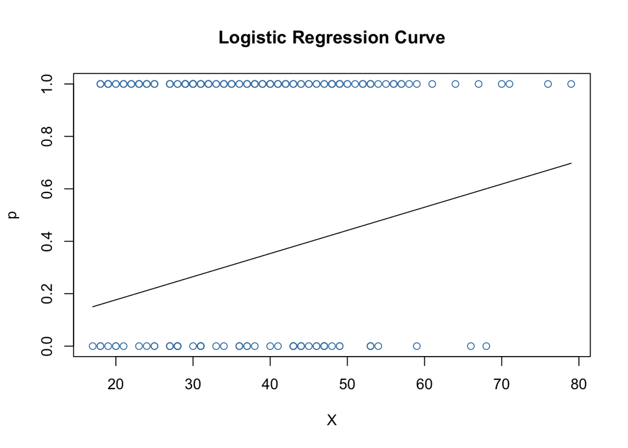

```r
log_curve(age, gender)
```

#### plot_metrics(y, X, alpha = 0.05)

The plot metrics uses the conf_matrix function to show the plot of accuracy in the confusion metrics.

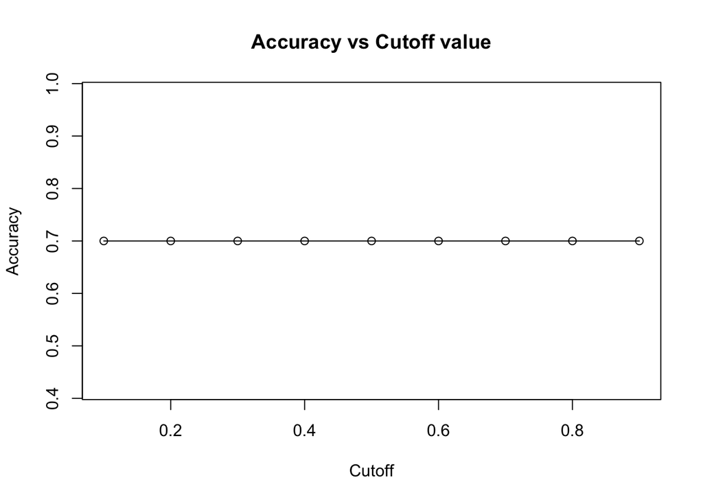

```r
plot_metrics(gender, age, alpha = 0.05)
```